# Cross-validation of regression models: mixed model examples

John Fox and Georges Monette

2023-09-24

The following artificial data set exemplifies a difference between cluster-based and individual-based cross-validation in hierarchical models.

It also shows how, in contrast with ordinary least-squares models, the variance at different levels of a hierarchical model need not necessarily become smaller as the model becomes larger.

In this example, the simplest random intercept model results in a between-cluster variance that is much smaller than that of a model that also includes $x$ as a predictor. Consequently, different methods of assessing model fit may result in different best models, underscoring the importance of assessing hierarchical models at different levels.

Adjusting the parameters generating this data can create an example that illustrates problems of non-convergence with hierarchical models. Fitted models with relatively small between-cluster variance, even simple random intercept models, are prone to non-convergence due to the nature of optimizing algorithms used in `lme` and `lmer`.

In some contexts, non-convergence, can be viewed as a diagnostic of a poor model. However, with a simple random intercept model where it may indicate a small between-cluster variance, non-convergence is an annoyance since it would be statistically correct to report that the data are consistent with a zero between-cluster population variance, i.e. that observed between-cluster variance in the data can be explained by the between-individual variability within clusters. This leads to perfectly valid statistical inferences. Although the calculation of accurate p-values for hypotheses concerning random effects may be complicated technically by the fact that the estimated variance is at the boundary of the parameter space, the estimated variance-covariance matrix of fixed-effect parameters will generally be non-singular and may be used for valid Wald tests of linear hypotheses of fixed-effect parameters.

Using cross-validation based on fitting random subsets compounds the problem since subsets on which there is non-convergence cause the cross-validation to fail unless non-converging subsets are omitted, which may bias results since non-convergence is likely to be related to the estimated between-cluster variances.

By varying the parameter for between-cluster variance, we can use the approach below to generate data sets with varying propensities to produce non-convergence in order to explore the consequences of non-convergence and to compare the performance of different optimizers. **to do**

At present, the results below are based on a data set that does not produce non-convergence and are limited to comparisons obtained by varying three factors:

- Three models: random intercept only, adding x as a predictor, and also adding the group means of x as a predictor,
- The method used for fitting: `lmer` in `lme4` or `lme` in `nlme`,
- Cross-validation resampling individual cases or resampling clusters.

Note that since the independence of clusters is a reasonable assumption while the independence of individual observations is not, cluster-based cross-validation has a stronger theoretical justification.

We start by generating and plotting the data.

```r
{
  # Generate data set

  # Parameters

  set.seed(123)
  Nb <- 10       # number of groups
  Nw <- 5        # number of individuals within groups
  Bb <- 0        # between group regression coefficient on group mean
  SDre <- 2.0    # between group SD of random level relative to group mean of X

  SDwithin <- 0.5    # within group SD

  Bw <- 1       # within group effect of X

  dd <- data.frame(
    group = factor(rep(1:Nb, each = Nw)),
    x = 20 + seq(1, Nb*Nw)
  ) %>%
    within(
      {
        xm  <- ave(x, group, FUN = mean) # withing group mean
        y <- 10 +
          Bb * xm +                  # contextual effect
          Bw * (x - xm) +            # within-group effect
          SDre * rnorm(Nb)[group] +  # random level by group
          SDwithin * rnorm(Nb*Nw)    # random error within groups
      }
    )
}
```

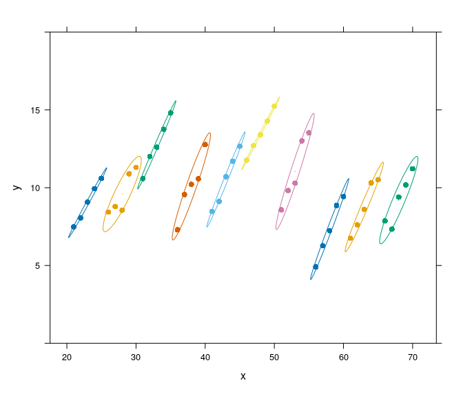

Hierarchical data set with 10 clusters

```r
pl <- xyplot(y ~ x, dd, groups = group,
             ylim = c(0,20),
             par.settings = list(superpose.symbol = list(pch = 16, cex = 1))) +
    latticeExtra::layer(panel.ellipse(...,center.cex =0))
pl
```

```r
pl <- update(pl, par.settings = list(superpose.symbol = list(pch = 1, cex = .7)))
```

The Y variable could represent scores on a programming aptitude test of 10 students of varying ages, each tested annually during a 5-year training program. The X variable is the age at which each test occurred.

We next obtain six fits with three models and two fitting functions.

```r
# random intercept models

fit0 <- lmer(y ~ 1 + (1|group), dd)
fit0l <- lme(y ~ 1, dd, random = ~ 1|group)

# effect of x and random intercept

fit1 <- lmer(y ~ x + (1|group), dd)
fit1l <- lme(y ~ x, dd, random = ~ 1|group)

# effect of x, mean of x and random intercept

fit2 <- lmer(y ~ x + xm + (1|group), dd)
fit2l <- lme(y ~ x + xm, dd, random = ~1|group)

modlist <- list(fit0, fit0l, fit1, fit1l, fit2, fit2l)
names(modlist) <- sapply(modlist, formula)
```

We can compare estimated fixed-effect coefficients.

```r
tbl <- do.call(compareCoefs, modlist)
     Calls:
     1: lmer(formula = y ~ 1 + (1 | group), data = dd)
     2: lme.formula(fixed = y ~ 1, data = dd, random = ~1 | group)
     3: lmer(formula = y ~ x + (1 | group), data = dd)
     4: lme.formula(fixed = y ~ x, data = dd, random = ~1 | group)
     5: lmer(formula = y ~ x + xm + (1 | group), data = dd)
     6: lme.formula(fixed = y ~ x + xm, data = dd, random = ~1 | group)

                 Model 1 Model 2 Model 3 Model 4 Model 5 Model 6
     (Intercept)  10.181  10.181 -35.371 -35.371  11.593  11.593
     SE            0.588   0.588   5.416   5.416   2.004   2.004

     x                            1.0012  1.0012  1.0204  1.0204
     SE                           0.0469  0.0469  0.0472  0.0472

     xm                                          -1.0514 -1.0514
     SE                                           0.0632  0.0632

tbl[] <- round(tbl,4)
tbl[is.na(tbl)] <- ''
kbl(tbl, align = 'r', caption = "Comparison of estimated fixed effects")
```

Comparison of estimated fixed effects

|  | Model 1 | Model 2 | Model 3 | Model 4 | Model 5 | Model 6 |
| --- | --- | --- | --- | --- | --- | --- |
| (Intercept) | 10.1812 | 10.1812 | -35.3714 | -35.3714 | 11.5925 | 11.5925 |
| SE | 0.5877 | 0.5877 | 5.4164 | 5.4164 | 2.0036 | 2.0036 |
| x |  |  | 1.0012 | 1.0012 | 1.0204 | 1.0204 |
| SE |  |  | 0.0469 | 0.0469 | 0.0472 | 0.0472 |
| xm |  |  |  |  | -1.0514 | -1.0514 |
| SE |  |  |  |  | 0.0632 | 0.0632 |

With this data set, the two functions `lme` and `lmer` converged for all models and produced consistent results. The differences between these two functions, and differences that depend on the optimizer used within each function, would manifest themselves if the data were generated with a smaller between-cluster variance.

We visualize predicted values using population predictions with the fixed effects model only and using BLUPs for random effects. Since `lme` and `lmer` produced almost identical results, the figures below are produced only with the `lmer` results.

```r
dd$fit_mod0__lmer.fe <- predict(fit0, re.form = ~ 0)
dd$fit_mod0__lmer.re <- predict(fit0)
dd$fit_mod0__lme.fe <- predict(fit0l, level = 0)
dd$fit_mod0__lme.re <- predict(fit0l, level = 1)

dd$fit_mod1__lmer.fe <- predict(fit1, re.form = ~ 0)
dd$fit_mod1__lmer.re <- predict(fit1)
dd$fit_mod1__lme.fe <- predict(fit1l, level = 0)
dd$fit_mod1__lme.re <- predict(fit1l, level = 1)

dd$fit_mod2__lmer.fe <- predict(fit2, re.form = ~ 0)
dd$fit_mod2__lmer.re <- predict(fit2)
dd$fit_mod2__lme.fe <- predict(fit2l, level = 0)
dd$fit_mod2__lme.re <- predict(fit2l, level = 1)

dl <- stats::reshape(dd, direction = 'long', sep = '.', timevar = 'effect', varying = grep('\\.', names(dd)))
dl$id <- 1:nrow(dl)
dl <- stats::reshape(dl, direction = 'long', sep = '__', timevar = 'method',  varying = grep('__', names(dl)))
dl$id <- 1:nrow(dl)
dl <- stats::reshape(dl, direction = 'long', sep = '_', timevar = 'modelcode',  varying = grep('_', names(dl)))

dl$model <- factor(c('~ 1', '~ 1 + x', '~ 1 + x + xm')[match(dl$modelcode, c('mod0','mod1','mod2'))])
```

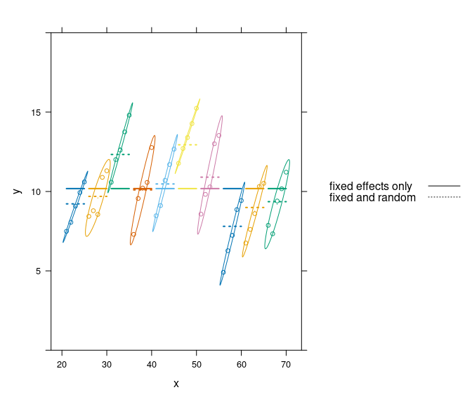

Fitted values using lmer with random intercept model

```r
(pl +
  xyplot(fit ~ x, subset(dl, modelcode == 'mod0' & effect == 'fe' & method == 'lmer'), groups = group, type = 'l', lwd =2) +
  xyplot(fit ~ x, subset(dl, modelcode == 'mod0' & effect == 're' & method == 'lmer'), groups = group, type = 'l', lwd =2, lty=3)
) %>% update(
  key=list(
    space = 'right',
    text = list(c('fixed effects only','fixed and random')),
    lines = list(lty=c(1,3))))
```

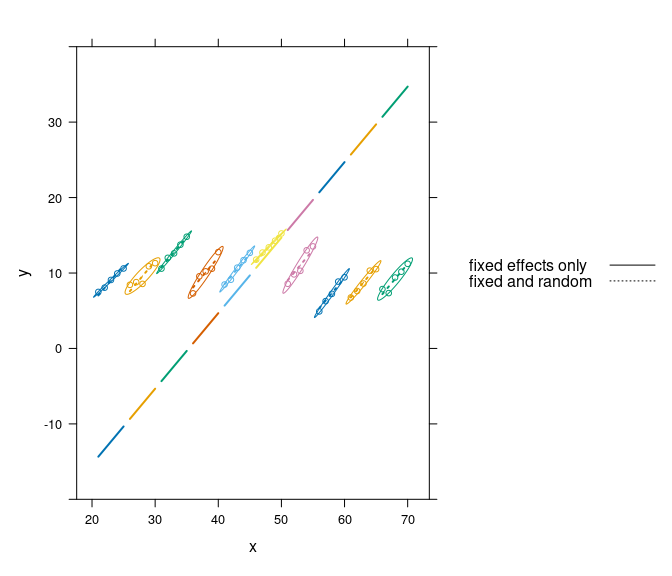

Fitted values using lmer with random intercept model and x as a predictor

```r
(pl +
  xyplot(fit ~ x, subset(dl, modelcode == 'mod1' & effect == 'fe' & method == 'lmer'), groups = group, type = 'l', lwd =2) +
  xyplot(fit ~ x, subset(dl, modelcode == 'mod1' & effect == 're' & method == 'lmer'), groups = group, type = 'l', lwd =2, lty=3)
) %>% update(
  ylim = c(-20,40),
  key=list(
    space = 'right',
    text = list(c('fixed effects only','fixed and random')),
    lines = list(lty=c(1,3))))
```

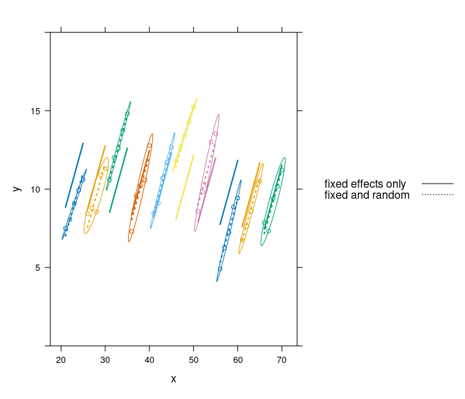

Fitted values using lmer with random intercept model and x and the group mean of x as predictors

```r
(pl +
  xyplot(fit ~ x, subset(dl, modelcode == 'mod2' & effect == 'fe' & method == 'lmer'), groups = group, type = 'l', lwd =2) +
  xyplot(fit ~ x, subset(dl, modelcode == 'mod2' & effect == 're' & method == 'lmer'), groups = group, type = 'l', lwd =2, lty=3)
) %>% update(
  ylim = c(0,20),
  key=list(
    space = 'right',
    text = list(c('fixed effects only','fixed and random')),
    lines = list(lty=c(1,3))))
```

### Cross-validation of models

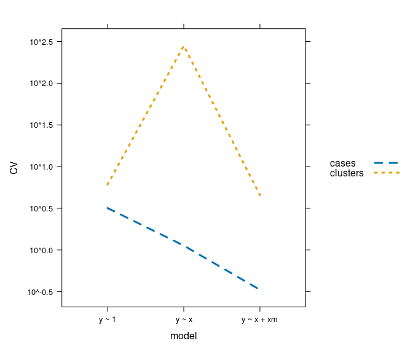

```r
cvs_cases <- lapply(modlist, cv) %>% lapply(rbind) %>% do.call(rbind,.)
     R RNG seed set to 807392
     R RNG seed set to 699700
     R RNG seed set to 376152
     R RNG seed set to 499374
     R RNG seed set to 829679
     R RNG seed set to 425917
cvs_clusters <- lapply(modlist, cv, cluster = 'group') %>% lapply(rbind) %>% do.call(rbind,.)

dout <- as.data.frame( rbind( cvs_cases, cvs_clusters))
# nrow(dout)
dout$cv_method <- rep(c('cases','clusters'), each = nrow(dout)/2)
dout$model <- rep(names(modlist), 2)
# dout$model <- factor(rep(c('~ 1','~ x','~ x + xm'), nrow(dout)/3))
dout$method <- rep(c('lmer','lme'), nrow(dout)/2)
dout$CV <- as.numeric(as.character(dout$`CV crit`))
dout$model <- factor(sub(' \\+ .1 .*$','', dout$model))

dout <- dout[order(dout$model),]
head(dout)
       CV crit adj CV crit full crit  k   seed clusters n clusters cv_method model
     1  3.1818      3.1209    2.3392 10 807392     NULL       NULL     cases y ~ 1
     2  3.6394      3.5513    2.3392 10 699700     NULL       NULL     cases y ~ 1
     7  6.0934       6.055    5.3643  n   NULL    group         10  clusters y ~ 1
     8  6.0934       6.055    5.3643  n   NULL    group         10  clusters y ~ 1
     3  1.1293     0.68703   0.17467 10 376152     NULL       NULL     cases y ~ x
     4  1.7455     0.92561   0.17467 10 499374     NULL       NULL     cases y ~ x
       method     CV
     1   lmer 3.1818
     2    lme 3.6394
     7   lmer 6.0934
     8    lme 6.0934
     3   lmer 1.1293
     4    lme 1.7455
xyplot(CV ~ model , subset(dout, method == 'lmer'), groups = cv_method,
       par.settings = list(superpose.line = list(lty=c(2,3),lwd = 3)),
       type = 'l',
       auto.key = T,
       scales = list(x = list(alternating = F), y = list(log=T)))
```